# Soil Profile Sketches

Author

D.E. Beaudette

Published

March 3, 2026

# Introduction

This is an expanded description of the arguments to `plotSPC()` and tips on making soil profile sketches look the way you want them to. Be sure to get the latest version of [aqp](https://github.com/ncss-tech/aqp/).

# Example Data

```r
library(aqp)
library(soilDB)

# some interesting soil series
s <- c('leon', 'musick', 'clarksville', 'pardee', 'lucy', 'pierre', 'drummer', 'zook', 'san joaquin')

# get basic morphology and extended data from SoilWeb cache
osds.full <- fetchOSD(s, extended = TRUE)

# save copy of SoilProfileCollection for later
osds <- osds.full$SPC
```

# Canvas

See the [SPC introduction for the basics](http://ncss-tech.github.io/AQP/aqp/aqp-intro.html#10_Plotting_SoilProfileCollection_Objects).

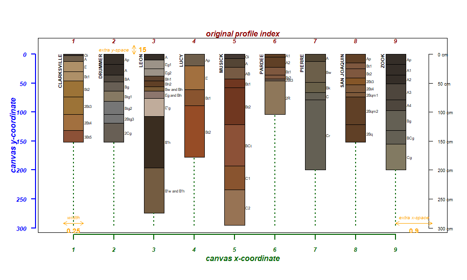

Graphical explanation of arguments used to adjust the layout of soil profile sketches by plotSPC().

```r
explainPlotSPC(osds)
```

# Arguments to `plotSPC`

Options can be used to conveniently specify sets of arguments that will be used in several calls to `plotSPC()` within a single R session. For example, arguments can be specified in a named list (`.a`) and set using: `options(.aqp.plotSPC.args = .a)`. Reset these options via `options(.aqp.plotSPC.args = NULL)`. Arguments explicitly passed to `plotSPC()` will override arguments set via `options()`.

## `x`

A `SoilProfileCollection` object with one or more profiles. Large collections (>25 profiles) may be hard to interpret on screen. Consider save the output directly to a PNG or PDF, for example:

```r
# start output device, dimensions are in pixels
png(filename = 'output.png', width = 1600, height = 800)

# plot
plotSPC(reallyBigSPC)

# close device, write file
dev.off()
```

Turning off ID and horizon designation annotation is another strategy for getting a quick glimpse of a large collection. Turning off profile and horizon boundary outlines with `divide.hz = FALSE` can help too.

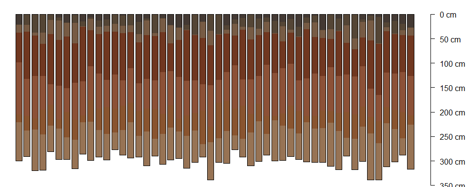

50 simulated variations of the Musick OSD pedon.

```r
# a single profile from our example
musick <- subset(osds, id == 'MUSICK')

# standard deviation of horizon boundary variation
horizons(musick)$hzb <- 10

# simulate 50 profiles
musick.sim <- perturb(musick, n = 50, boundary.attr = 'hzb')

# no margins
par(mar = c(0, 0, 0, 0))
# note other arguments used to improve legibility
plotSPC(musick.sim, print.id = FALSE, name = NA, width = 0.4, divide.hz = FALSE, depth.axis = list(line = -4, cex = 1))
```

## Profile Arrangement

### n

A single integer describing the amount of space along x-axis to allocate, defaults to `length(x)`.

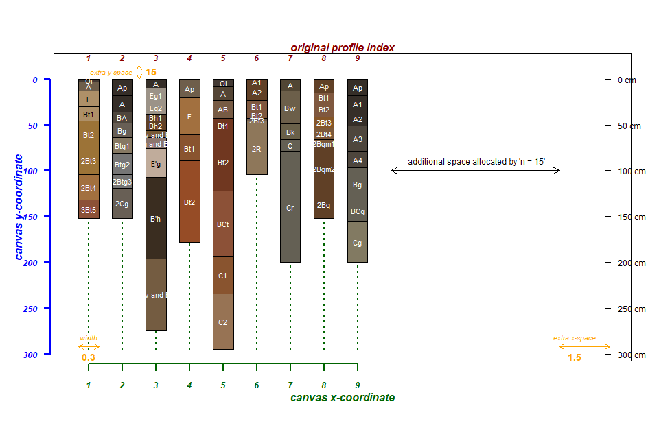

A demonstration of the extra space allocated by adjusting the `n` argument.

```r
explainPlotSPC(osds, cex.names = 0.66, width = 0.3, n = 15, print.id = FALSE, name.style = 'center-center')

text(x = 10.5, y = 90, label = "additional space allocated by 'n = 15'", adj = 0, cex = 0.75)
arrows(x0 = length(osds) + 1, x1 = 15, y0 = 100, y1 = 100, code = 3, length = 0.1)
```

### plot.order

An integer vector describing the order in which soil profiles should be plotted. The ordering vector may contain duplicates, but may not include values outside the range of $[1, length(x)]$.

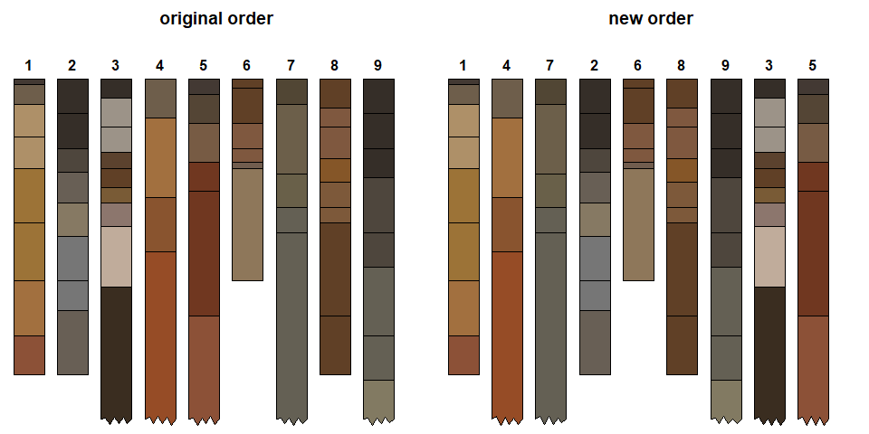

A graphical demonstration of changing the profile plotting order as specified using an integer index.

```r
# integer labels encoding original order
site(osds)$original.order <- 1:length(osds)

# shuffle ordering vector
idx  <- sample(osds$original.order)

# re-ordering index may contain duplicates
# idx <- rep(1:2, length.out = length(osds))


# setup margins, multi-figures
par(mar = c(0, 0, 2, 0), mfcol = c(1, 2))
plotSPC(osds, depth.axis = FALSE, label = 'original.order', name = NA, width = 0.35, cex.id = 1, max.depth = 175)
title('original order')

plotSPC(osds, depth.axis = FALSE, label = 'original.order', plot.order = idx, name = NA, width = 0.35, cex.id = 1, max.depth = 175)
title('new order')
```

### relative.pos

vector of relative positions along the x-axis, within {1, n}, ignores plot.order see details

### add

When `TRUE`, sketches and annotations (like a depth axis) are added to the current output device. With careful use of `x.idx.offset` it is possible to combine several sets of profiles, such as the results of a simulation (see [`perturb()`](http://ncss-tech.github.io/aqp/reference/perturb.html)). With careful use of `scaling.factor`, profiles can be added to any figure.

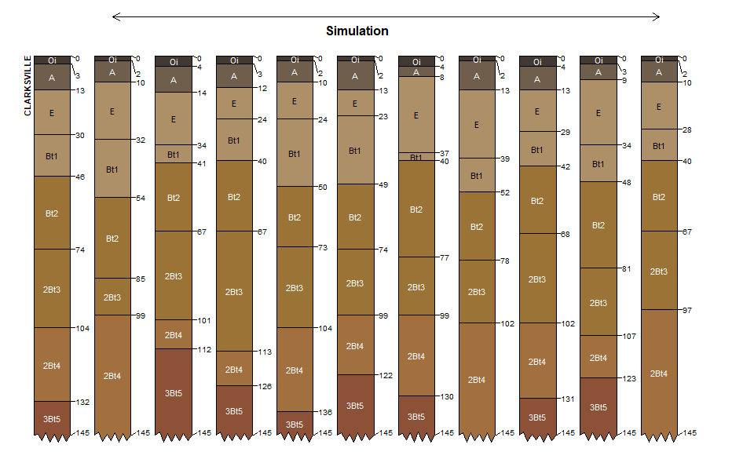

```r
# select first profile
x <- osds[1, ]

# convert horizon distinctness codes
# to a horizon boundary "variability" index
horizons(x)$hzd <- hzDistinctnessCodeToOffset(x$distinctness) * 2

# generate 10 simulations
x.sim <- perturb(x, n = 10, boundary.attr = 'hzd')

# margins
par(mar = c(0, 0, 0, 0))

# plot the source profile, leaving room for 11 profiles (n = 11)
plotSPC(x, cex.names = 0.66, name.style = 'center-center', width = 0.3, depth.axis = FALSE, hz.depths = TRUE, hz.depths.offset = 0.05, n = 11, id.style = 'side', cex.id = 0.66, fixLabelCollisions = TRUE, max.depth = 145)

# add 10 simulations, offset 1 position to the right with x.idx.offset = 1
plotSPC(x.sim, cex.names = 0.66, name.style = 'center-center', width = 0.3, depth.axis = FALSE, hz.depths = TRUE, hz.depths.offset = 0.05, print.id = FALSE, add = TRUE, x.idx.offset = 1, fixLabelCollisions = TRUE, max.depth = 145)

# annotate simulations
arrows(x0 = 2, x1 = 11, y0 = -15, y1 = -15, length = 0.1, code = 3)
mtext('Simulation', side = 3, at = 5.5, line = -2.5, font = 2, adj = 0)
```

### x.idx.offset

Horizontal offset from 0 (left-hand edge), used to shift all profiles left or right within the sketch. Sometimes this is useful for making small, aesthetic adjustments especially when making sketches of large collections. When used together with the `add` argument, it is possible to align multiple versions of the same data by shifting profiles left or right. The following example adds profile sketches that use dry soil colors next to the original (moist soil colors) sketches.

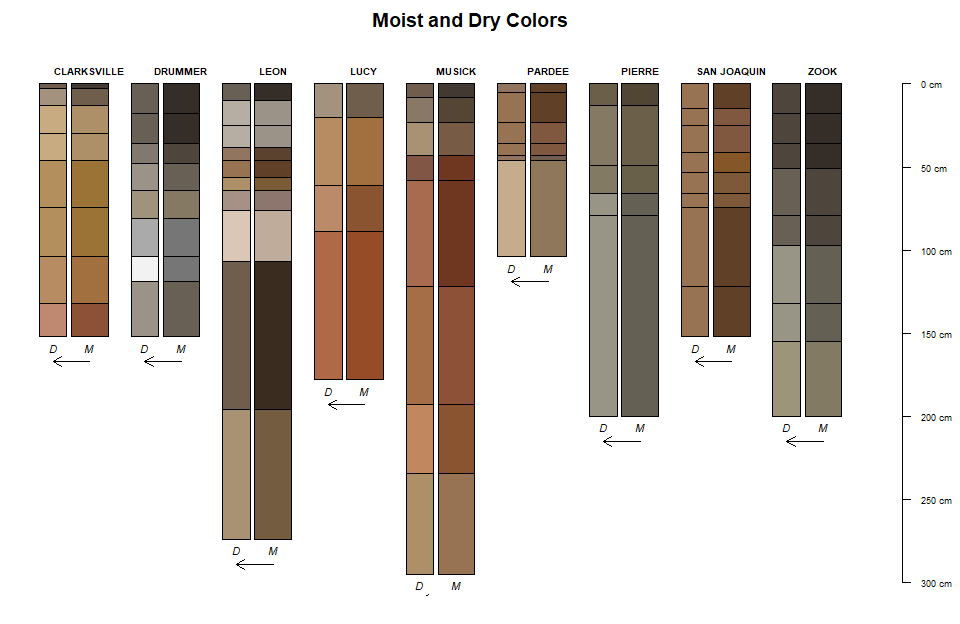

```r
# convert dry colors to hex notation
osds$dry_color <- munsell2rgb(osds$dry_hue, osds$dry_value, osds$dry_chroma)

# adjust margins
par(mar = c(1.5, 0, 2, 1))

# original data, supress horizon designations
plotSPC(osds, width = 0.2, name = NA)

# add and shift dry color sketches to the left (-0.4 units)
plotSPC(osds, width = 0.15, cex.names = 0.66, depth.axis = FALSE, print.id = FALSE, name = NA, x.idx.offset = -0.4, add = TRUE, color = 'dry_color')

# a title
title('Moist and Dry Colors')

# demonstrate shift with an arrow below each profile
s <- 1:length(osds)
bottoms <- profileApply(osds, max) + 15
arrows(x0 = s, y0 = bottoms, x1 = s - 0.4, y1 = bottoms, length = 0.1)

# annotate moist vs. dry
text(x = s, y = bottoms, labels = 'M', pos = 3, font = 3, cex = 0.66)
text(x = s - 0.4, y = bottoms, labels = 'D', pos = 3, font = 3, cex = 0.66)
```

### y.offset

Either a single value or numeric vector of vertical offsets with `length == length(x)`, in depth units of `x`. Profile sketches and depth axis are shifted when using a single y offset value. The depth axis is disabled when using multiple y offsets. Note: `y.offset` is automatically re-ordered by `plot.order`.

Shift all profile sketches down 300cm, leaving room for additional annotation above. Right-hand axis added for clarity.

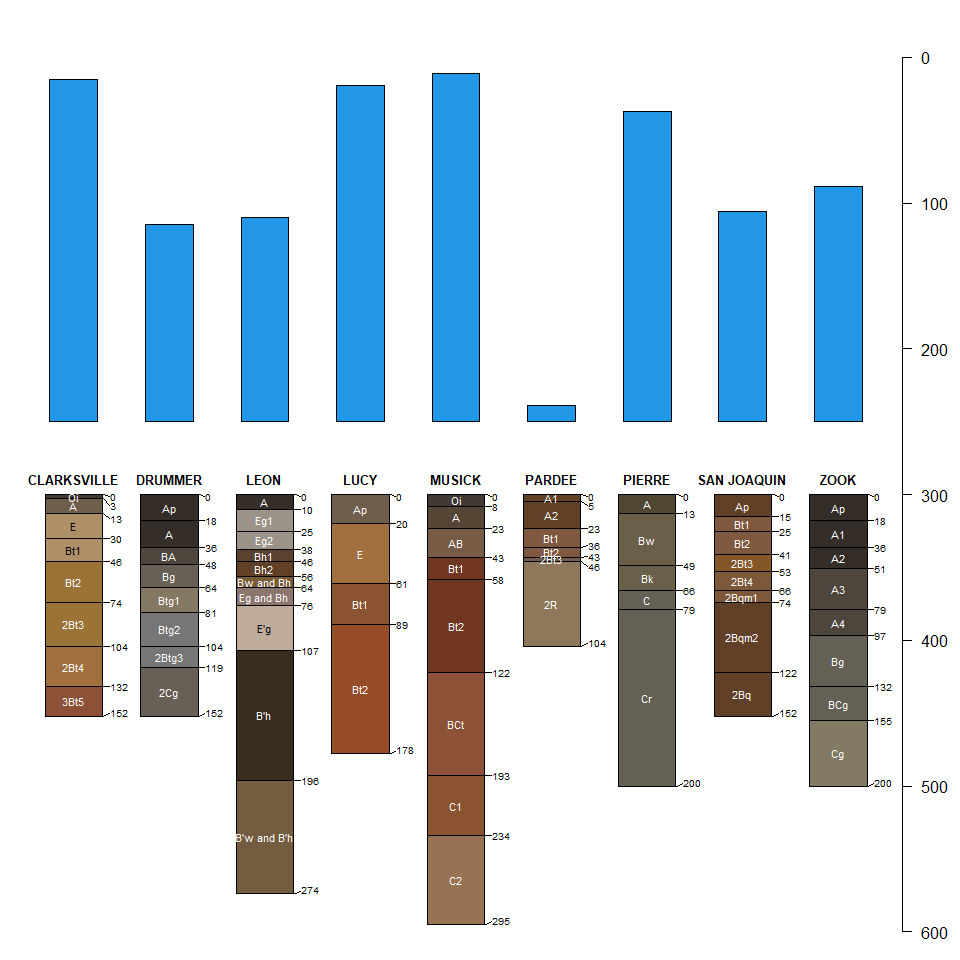

```r
par(mar = c(0, 0, 0, 0))

plotSPC(osds, cex.names = 0.66, name.style = 'center-center', width = 0.3, y.offset = 300, hz.depths = TRUE, fixLabelCollisions = TRUE, hz.depths.offset = 0.05, depth.axis = FALSE)

# fake data
rect(xleft = (1:length(osds)) - 0.25, xright = (1:length(osds)) + 0.25, ybottom = 250, ytop = runif(n = length(osds), min = 0, max = 250), col = 4)

# demonstrate full y-range within figure
axis(side = 4, line = -3, las = 1)
```

Shift each profile sketch a different amount. Transect or cross-section figures can be manually created in this way. See also `scaling.factor` for applying a vertical scaling to all profiles.

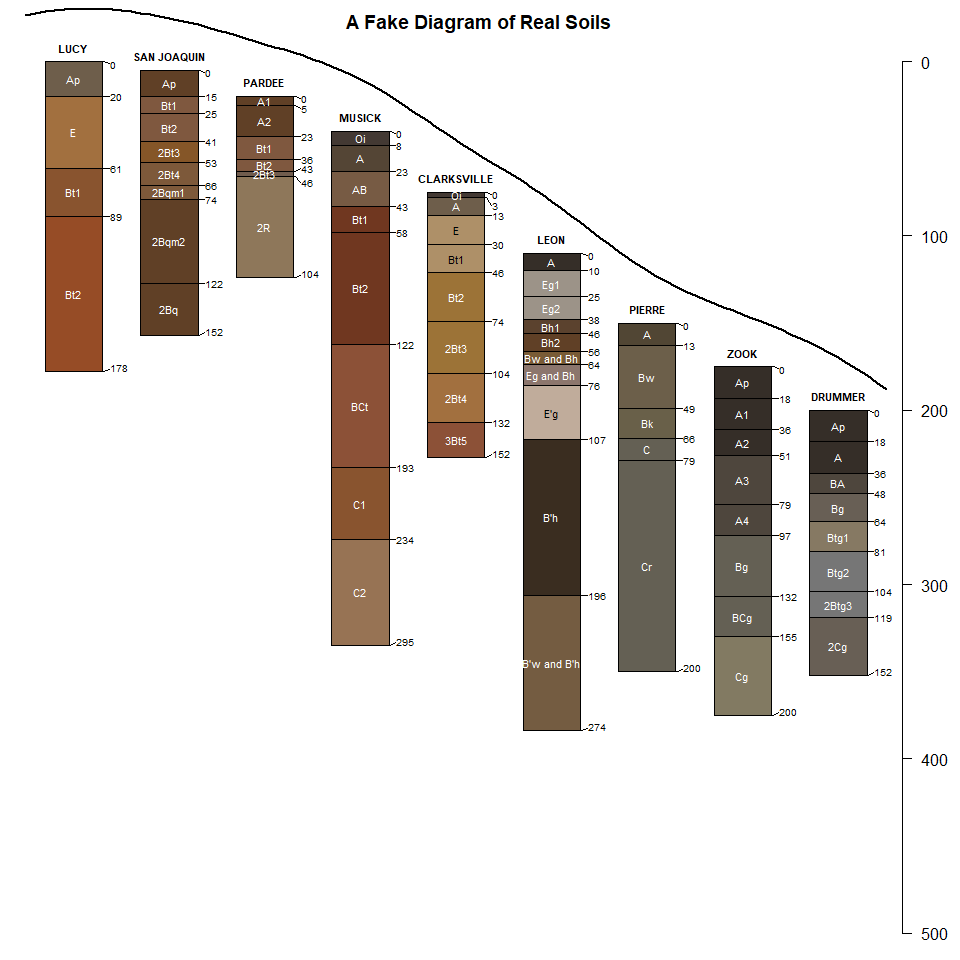

```r
# manually create a nice looking set of relative elevations along a pretend landform
.yshift <- c(0, 1, 4, 8, 15, 22, 30, 35, 40) * 5

# compute the Hurst Redness Index for each horizon
# this is a horizon-level attribute
osds$hr <- hurst.redness(osds$hue, osds$value, osds$chroma)

# compute the profile median of Hurst Redness Index
# this is now a site-level attribute
osds$profile.median.hr <- profileApply(osds, function(i) median(i$hr, na.rm = TRUE))

# rank profile median, Hurst Redness Index
# use this to sort profiles
o <- order(osds$profile.median.hr)

# however, this will complicate a manual specification of the landform surface
# now we need an index back to the original order
idx <- match(1:length(osds), o)

# margins
par(mar = c(0, 0, 0, 0))

# apply profile-specific y-offsets
# re-arrange horizontal position with 'plot.order = o'
plotSPC(osds, cex.id = 0.66, cex.names = 0.66, name.style = 'center-center', width = 0.3, y.offset = .yshift[idx], hz.depths = TRUE, fixLabelCollisions = TRUE, hz.depths.offset = 0.05, plot.order = o)

# demonstrate full y-range within figure
axis(side = 4, line = -3, las = 1)

# add idealized land surface
.xland <- 1:length(osds)
.yland <- .yshift - 30

# smooth via interpolation
.landSurface <- splinefun(.xland, .yland)
.s <- seq(0.5, length(osds) + 0.5, by = 0.1)

# add smoothed, idealized land surface
lines(x = .s, y = .landSurface(.s), lwd = 2)

# remind ourselves that this is fake
title('A Fake Diagram of Real Soils', line= -1.5)
```

## Profile Styling

### max.depth

Set the maximum depth for soil profile sketches, given in the same units as used by the `SoilProfileCollection`. Profiles deeper than `max.depth` are truncated and marked with a “ragged” bottom boundary. Values deeper than the deepest profiles in the collection (e.g. `max(x)`) will extend the vertical dimension of the sketch to `max.depth`. This can be a handy way to include extra space below profile sketches for additional annotation.

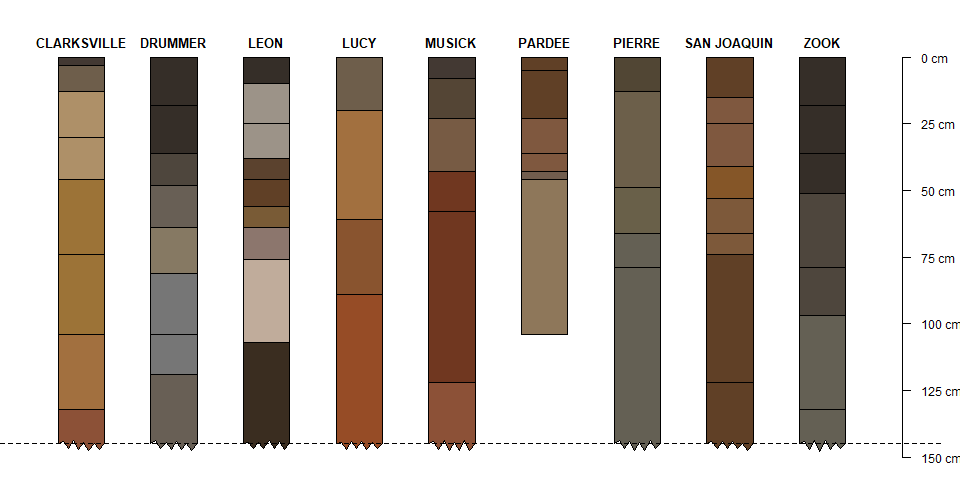

```r
par(mar = c(1, 0, 0, 1))

plotSPC(osds, cex.names = 0.66, name = NA, max.depth = 145)

# SPC truncated at 145cm
abline(h = 145, lty = 2)
```

### width

Each profile is given 1 horizontal unit of space in the figure. The `width` argument is given as 1/2 of this space: typically ranging from 0.1–0.4. Values >= 0.5 will cause overlap.

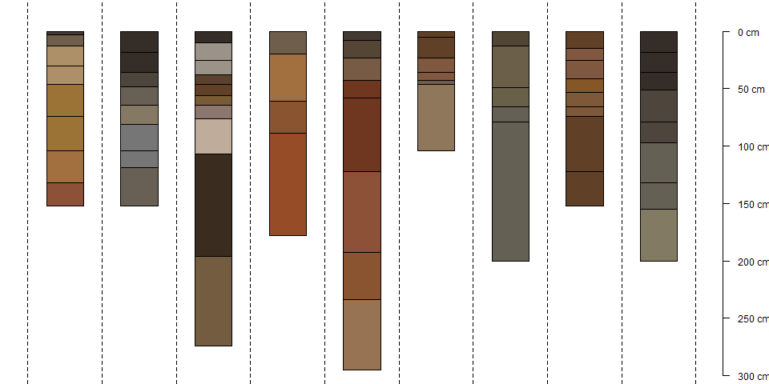

```r
par(mar = c(0, 0, 0, 1))

plotSPC(osds, cex.names = 0.66, print.id = FALSE, name = NA)

# annotate horizontal space allocated to each profile
abline(v = seq(0.5, length(osds) + 0.5, by = 1), lty = 2)
```

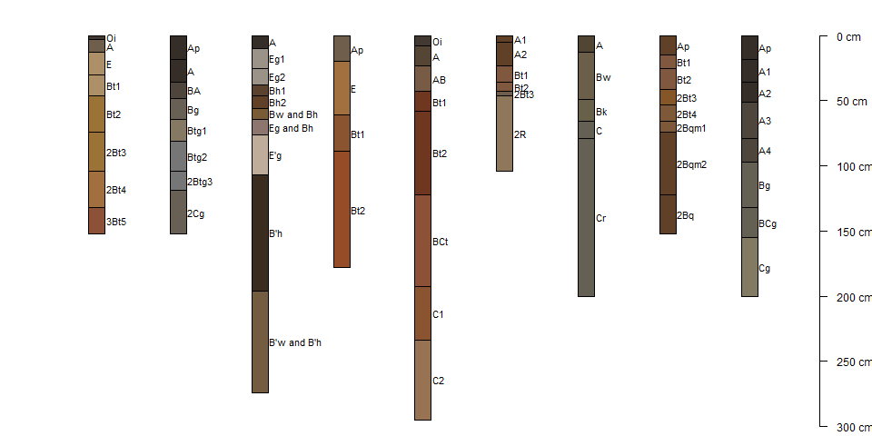

```r
par(mar = c(0, 0, 0, 1))

# too skinny, but lots of room for extra annotation
plotSPC(osds, width = 0.1, cex.names = 0.66, print.id = FALSE)
```

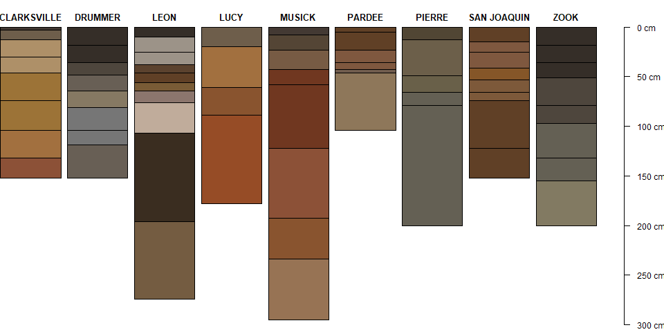

```r
# works OK without horizon designations on the right side
plotSPC(osds, width = 0.45, cex.names = 0.66, name = NA)
```

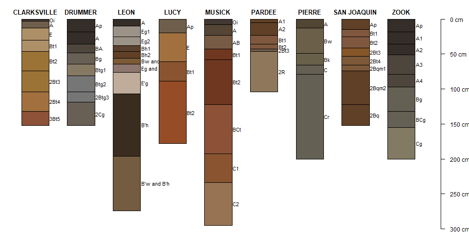

```r
# about right
plotSPC(osds, width = 0.3, cex.names = 0.66)
```

### scaling.factor

vertical scaling of profile depths, useful for adding profiles to an existing figure

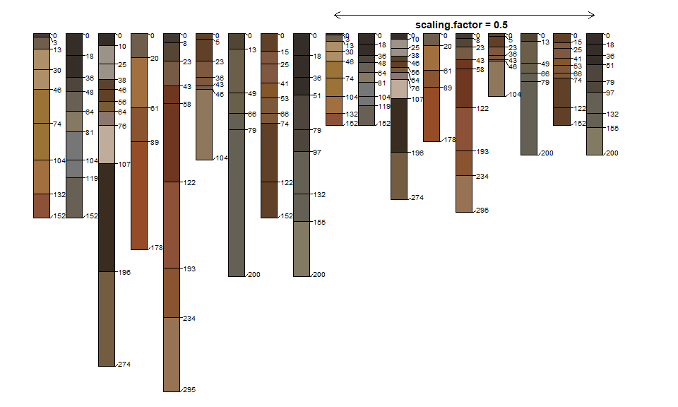

```r
# margins
par(mar = c(0, 0, 0, 0))

# plot the source profile, leaving room for 11 profiles (n = 11)
plotSPC(osds, cex.names = 0.66, name = NA, width = 0.25, depth.axis = FALSE, hz.depths = TRUE, n = length(osds) * 2, print.id = FALSE, fixLabelCollisions = TRUE, hz.depths.offset = 0.05)

plotSPC(osds, cex.names = 0.66, name = NA, width = 0.25, depth.axis = FALSE, hz.depths = TRUE, print.id = FALSE, add = TRUE, x.idx.offset = length(osds), scaling.factor = 0.5, fixLabelCollisions = TRUE, hz.depths.offset = 0.05)

arrows(x0 = length(osds) + 1, x1 = length(osds) * 2, y0 = -15, y1 = -15, length = 0.1, code = 3)
mtext('scaling.factor = 0.5', side = 3, at = 12.5, line = -2.25, font = 2, adj = 0, cex = 0.85)
```

### lwd

line width multiplier used for sketches

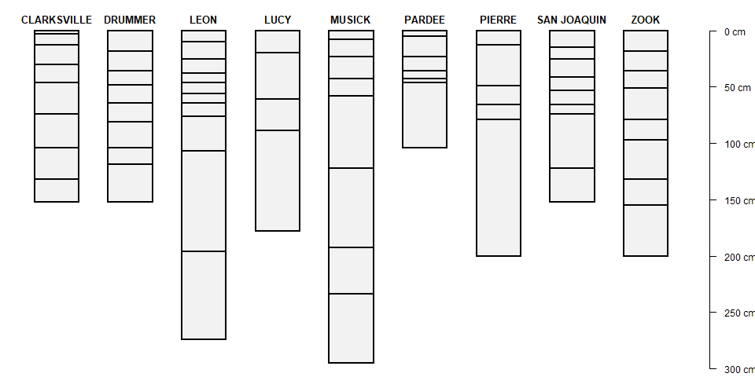

```r
par(mar = c(0, 0, 0, 1))
plotSPC(osds, cex.names = 0.66, name.style = 'center-center', width = 0.3, lwd = 2, color = NA, name = NA)
```

### lty

line style used for all sketches

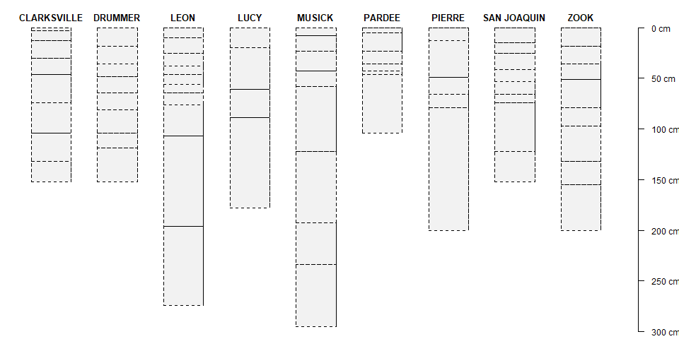

```r
par(mar = c(0, 0, 0, 1))
plotSPC(osds, cex.names = 0.66, name.style = 'center-center', width = 0.3, lty = 2, color = NA, name = NA)
```

## Horizon Styling

### color

A quoted column name containing R-compatible color descriptions (e.g. `#7A5C37FF`, approximately 10YR 4/4), or numeric / categorical data to be displayed thematically.

Numeric values.

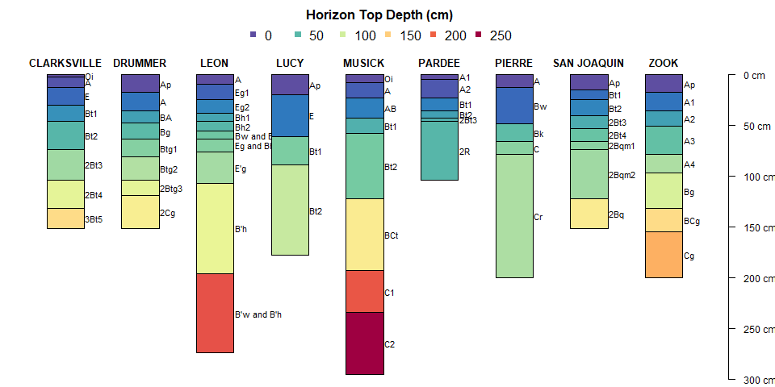

```r
# leave room at the top for a legend, and on the right hand side for depth axis.
par(mar = c(0, 0, 3, 1))

# horizon top depth
plotSPC(osds, color = 'top', col.label = 'Horizon Top Depth (cm)', cex.names = 0.66)
```

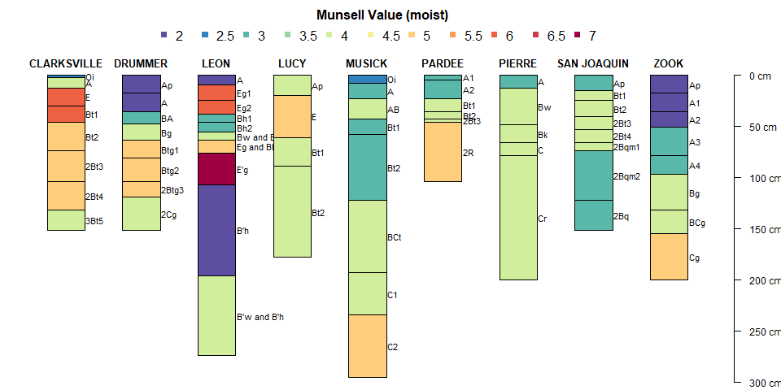

```r
plotSPC(osds, color = 'value', col.label = 'Munsell Value (moist)', cex.names = 0.66)
```

Categorical values.

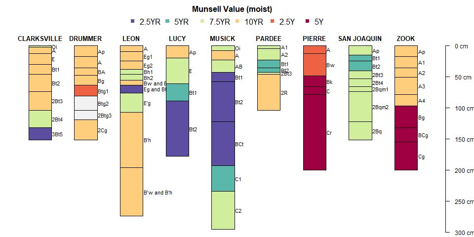

```r
# set ordering of Munsell hue according to hue position
osds$hue_ordered <- factor(osds$hue, levels = huePosition(returnHues = TRUE))

# leave room at the top for a legend, and on the right hand side for depth axis.
par(mar = c(0, 0, 3, 1))

plotSPC(osds, color = 'hue_ordered', col.label = 'Munsell Value (moist)', cex.names = 0.66)
```

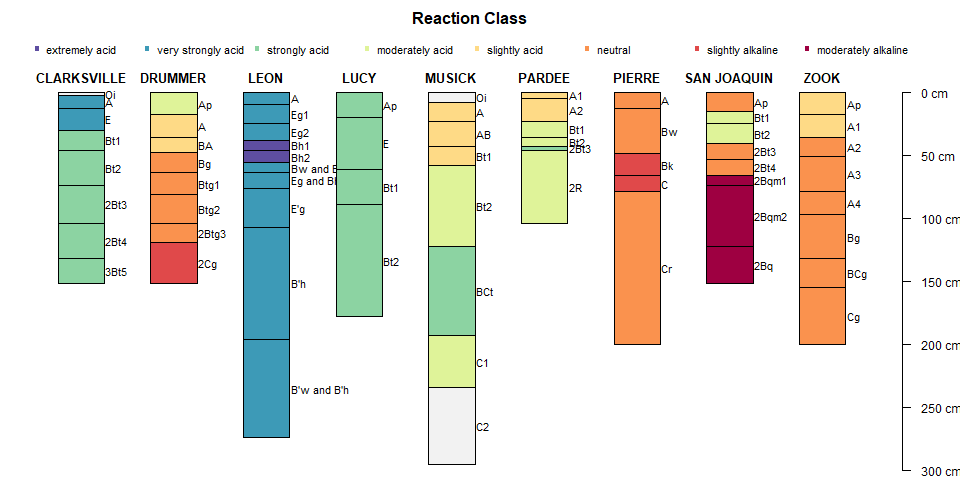

```r
# reaction class is already an ordered factor, set in fetchOSD()
plotSPC(osds, color = 'pH_class', col.label = 'Reaction Class', cex.names = 0.66, col.legend.cex = 0.66)
```

User-defined colors in hex notation.

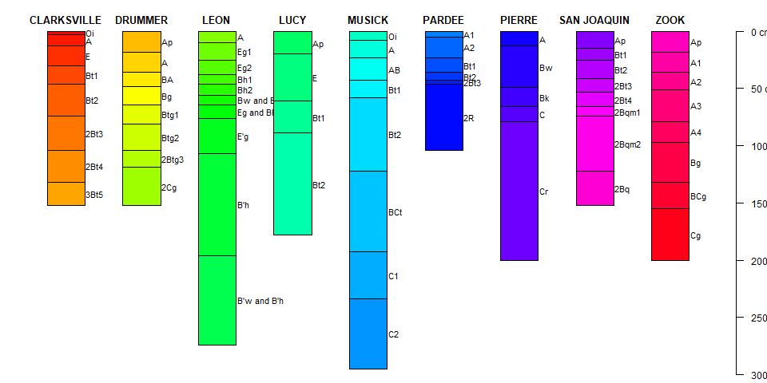

```r
# assign each horizon a color of the rainbow
horizons(osds)$rainbowColors <- rainbow(n = nrow(osds))

par(mar = c(0, 0, 0, 0))
plotSPC(osds, color = 'rainbowColors', cex.names = 0.66, col.legend.cex = 0.66)
```

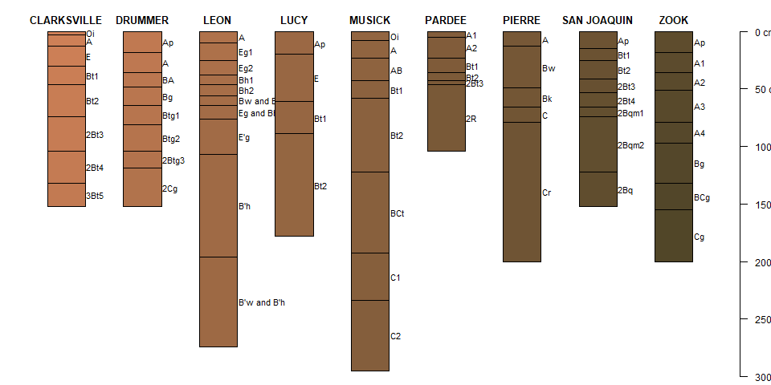

```r
# color gradient from 2.5YR 6/8 -> 5Y 3/3
cr <- colorRampPalette(parseMunsell(c('2.5YR 6/8', '5Y 3/3')), space = 'Lab', interpolate = 'spline')

horizons(osds)$gradientColors <- cr(n = nrow(osds))

plotSPC(osds, color = 'gradientColors', cex.names = 0.66, col.legend.cex = 0.66)
```

### density

fill density used for horizon color shading, either a single integer or a quoted column name (horizon-level attribute) containing integer values (default is `NULL`, no shading)

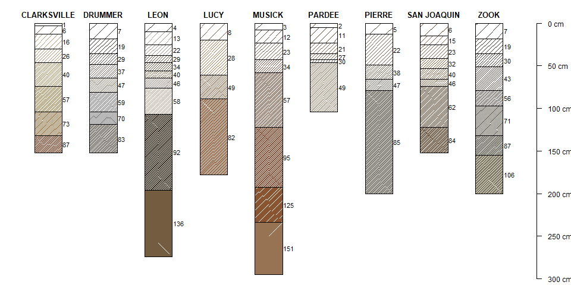

```r
# make an index for shading density, based on horizon mid-points
# rescale slightly with power transform
osds$density.shading <- round(((osds$bottom + osds$top) / 2)^0.9)

par(mar = c(0, 0, 0, 1))
plotSPC(osds, cex.names = 0.66, density = 'density.shading')
```

### show.legend

logical, show legend? (default is TRUE)

### col.label

thematic legend title

### col.palette

color palette used for thematic sketches (default is `rev(brewer.pal(10, 'Spectral'))`)

### col.palette.bias

color ramp bias (skew), see `colorRamp`

### col.legend.cex

scaling of thematic legend

### n.legend

approximate number of classes used in numeric legend, max number of items per row in categorical legend

### default.color

default horizon fill color used when color attribute is `NA`. This can be a useful setting when highlighting horizons that are missing data or colors.

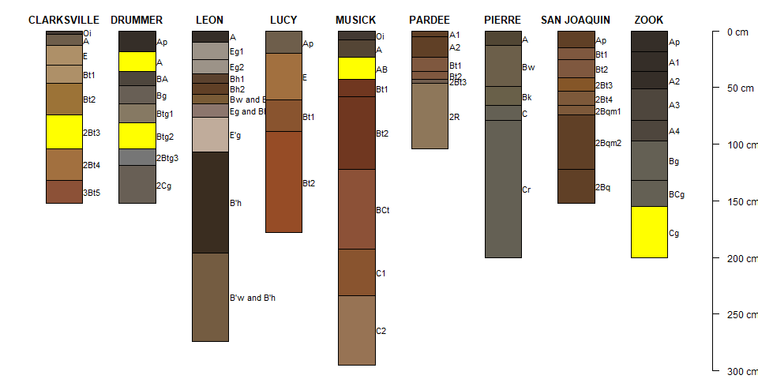

```r
# remove some colors at random
osds$soil_color.NA <- osds$soil_color
osds$soil_color.NA[sample(1:nrow(osds), size = 5)] <- NA

par(mar = c(0, 0, 0, 1))
plotSPC(osds, cex.names = 0.66, color = 'soil_color.NA', default.color = 'yellow')
```

## Annotation / Labeling

### name

Quoted column name of the (horizon-level) attribute containing horizon designations or labels, if missing `hzdesgnname(x)` is used. Suppress horizon name printing by setting `name = NA` or `name = ''`.

### name.style

Horizon designation label style, one of `c('right-center', 'center-center', 'left-center', 'left-top', 'center-top'))`. The `right-center` position has been the default in **aqp** since 2010. I prefer the `center-center` style. Note that horizon designation label colors are automatically adjusted for maximum contrast (by `invertLabelColor()`) when placed inside of a profile sketch.

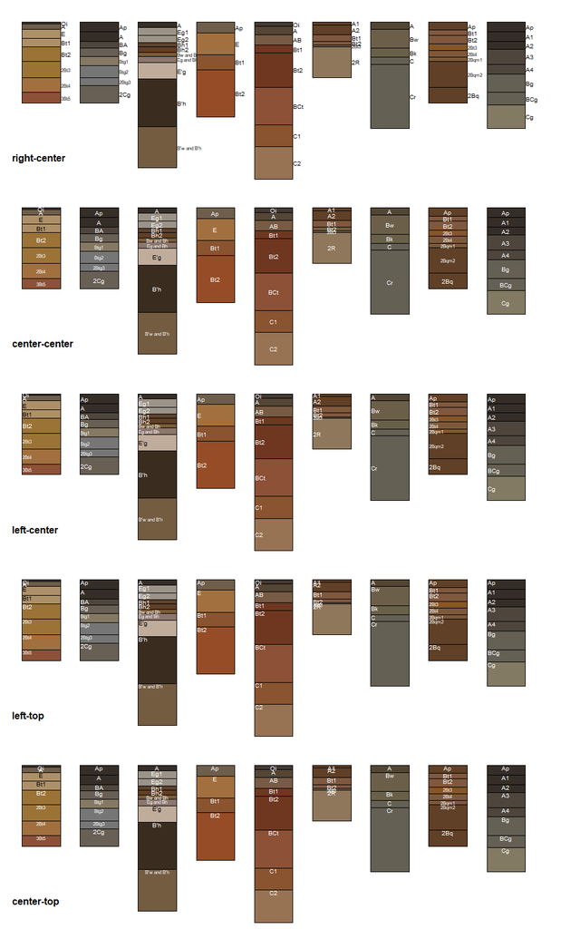

```r
par(mar=c(0,0,1,0), mfcol=c(5,1))

for(i in c('right-center', 'center-center', 'left-center', 'left-top', 'center-top')) {
  plotSPC(osds, width = 0.33, cex.names = 0.9, shrink=TRUE, print.id = FALSE, plot.depth.axis=FALSE, name.style=i)
  mtext(text = i, at = 0.5, side=1, line=-4, cex=1, adj = 0, font = 2)
}
```

### shrink

logical, reduce character scaling for ‘long’ horizon by 80%

### shrink.cutoff

character length defining ‘long’ horizon names

### shrink.thin

integer, horizon thickness threshold for shrinking horizon names by 80%, only activated when shrink = TRUE (NULL = no shrinkage)

### abbr

logical, abbreviate label

### abbr.cutoff

suggested minimum length for abbreviated label

### label

A single (quoted) site-level attribute name that will be used to label profiles. This defaults to `idname(x)` (e.g. the profile ID), but can be anything in `site(x)`. See `id.style` argument for adjusting side vs. top vs. automatic label positioning. Suppress printing of profile labels with `print.id = FALSE`.

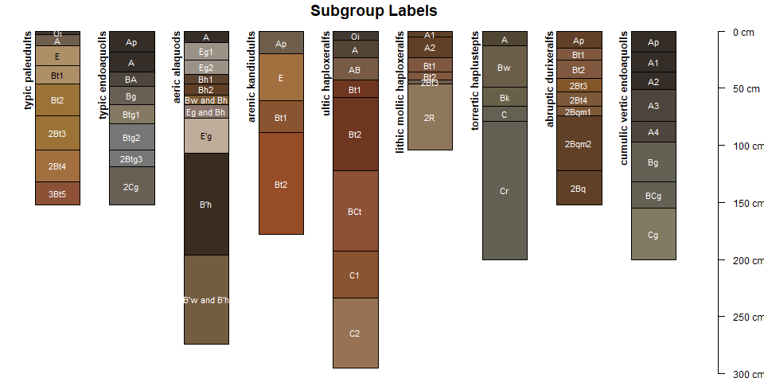

```r
par(mar = c(0, 0, 0, 1))
plotSPC(osds, cex.names = 0.66, label = 'subgroup', name.style = 'center-center', width = 0.3)
title('Subgroup Labels', line = -1)
```

### hz.depths

When `TRUE`, small horizon depth labels are placed just to the right of horizon top depths (right justified). The results may be illegible if there are too many profiles in the collection or if profiles are too wide. Works best with `name.style = 'center-center'` and `depth.axis = FALSE`.

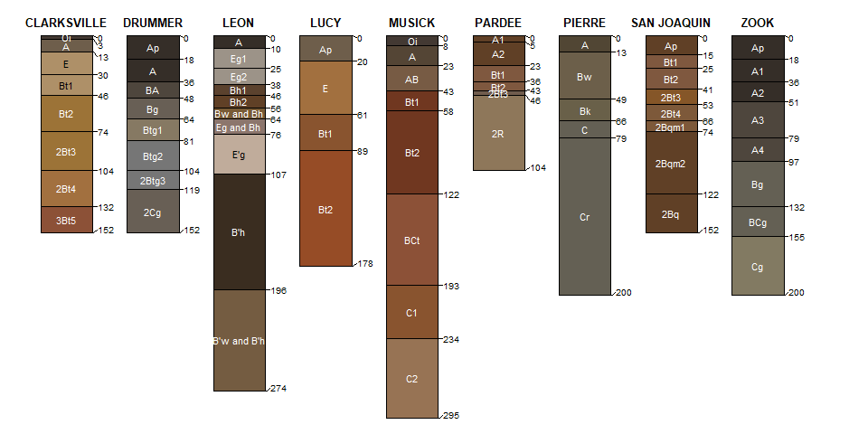

```r
par(mar = c(0, 0, 0, 0))
plotSPC(osds, cex.names = 0.66, name.style = 'center-center', width = 0.3, depth.axis = FALSE, hz.depths = TRUE)
```

### hz.depths.offset

Numeric values between 0.01–0.15 shift horizon depth annotation to the right of profile sketches.

```r
par(mar = c(0, 0, 0, 0))
plotSPC(osds, cex.names = 0.66, name.style = 'center-center', width = 0.3, depth.axis = FALSE, hz.depths = TRUE, hz.depths.offset = 0.05)
```

[output not shown]

### hz.depths.lines

When `TRUE`, segments are drawn between horizon depth labels and actual horizon depth; this is useful when including horizon boundary distinctness and/or when `fixLabelCollisions = TRUE`.

```r
par(mar = c(0, 0, 0, 0))
plotSPC(osds, cex.names = 0.66, name.style = 'center-center', width = 0.3, depth.axis = FALSE, hz.depths = TRUE, hz.depths.offset = 0.05, hz.depths.lines = TRUE)
```

[output not shown]

### fixLabelCollisions

When `TRUE`, use `aqp::fixOverlap()` to attempt fixing horizon depth labeling collisions. This will slow plotting of large collections. Enabling fixes also sets `hz.depths.lines = TRUE`. A simulation of electrostatic charges is used to iteratively adjust labels until there is no overlap. See `?electroStatics_1D` for details.

```r
par(mar = c(0, 0, 0, 0))
plotSPC(osds, cex.names = 0.66, name.style = 'center-center', width = 0.3, depth.axis = FALSE, hz.depths = TRUE, hz.depths.offset = 0.05, fixLabelCollisions = TRUE)
```

[output not shown]

### fixOverlapArgs

Pass additional arguments to `fixOverlap()` as a `list`. Fix overlapping labels with simulated annealing. Adjustments made by this method involve random permutations, so output is different each time. Use `set.seed` when you need consistent results. See `?SANN_1D` for details.

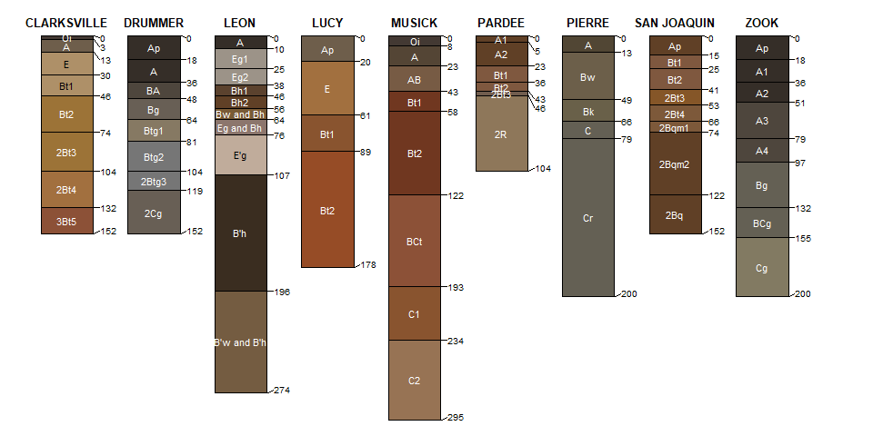

```r
par(mar = c(0, 0, 0, 0))
plotSPC(osds, cex.names = 0.66, name.style = 'center-center', width = 0.3, depth.axis = FALSE, hz.depths = TRUE, hz.depths.offset = 0.05, fixLabelCollisions = TRUE, fixOverlapArgs = list(method = 'S'))
```

### alt.label and alt.label.col

A single (quoted) site-level attribute name that will be used as secondary annotation, inset just below the top of each profile. Note that the `alt.label.col` argument will probably have to be used for legibility.

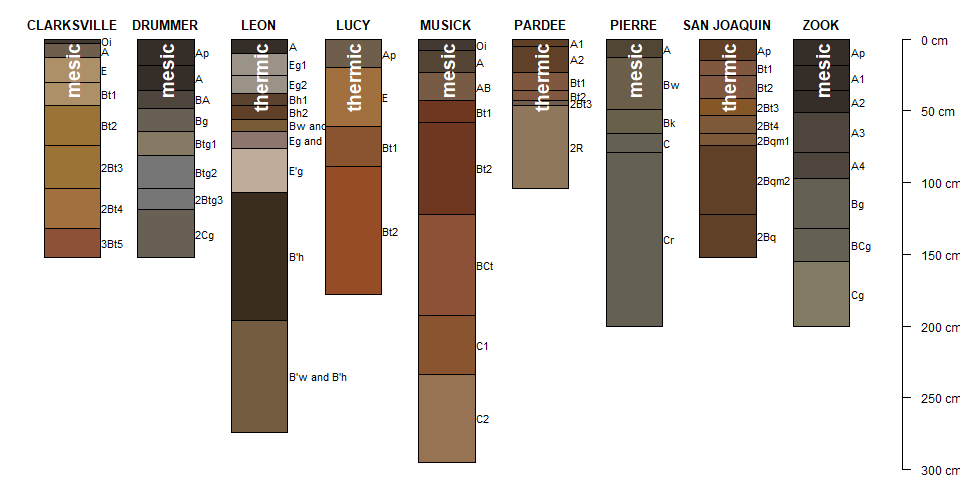

```r
par(mar = c(0, 0, 0, 1))
plotSPC(osds, cex.names = 0.66, alt.label = 'tax_tempcl', width = 0.3, alt.label.col = 'white')
```

### cex.names

This is a baseline scaling factor applied to all labels in the figure: ID labels, horizon designations, horizon depths, and depth axis. Values around `0.6` are usually just about right.

### id.style

Profile ID annotation style. The default value of `auto` uses a simple heuristic used to select from:

- `top`: centered above each profile
- `side`: along the top-left edge of profiles

### cex.id

Scaling factor applied to the profile IDs.

### font.id

Font style applied to the profile IDs, default is `2` (bold).

### offset.id

Vertical offset applied to profile ID, only when `id.style = 'top'`

## Horizon Boundaries

### raggedBottom

A quoted column name of the (site-level) attribute (logical) used to mark profiles with a truncated lower boundary. This type of annotation is a convenient way to demonstrate that soil, paralithic material, or bedrock contact likely extends below the depth of excavation.

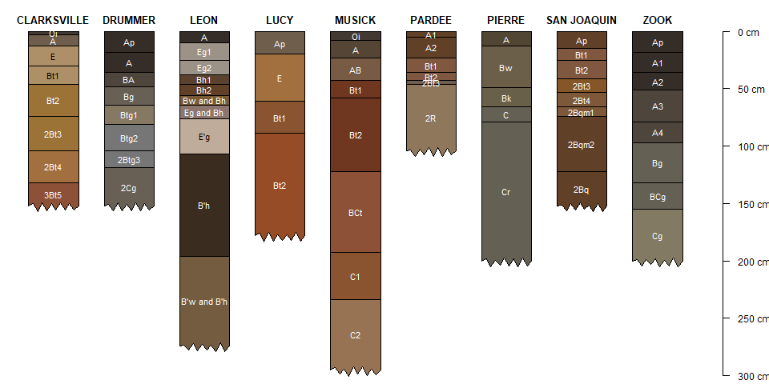

```r
par(mar = c(0, 0, 0, 1))

# flag all profiles as being incomplete / truncated
site(osds)$rb <- TRUE

plotSPC(osds, cex.names = 0.66, raggedBottom = 'rb', width = 0.33, name.style = 'center-center')
```

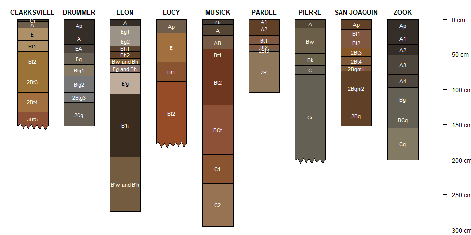

```r
# flag some profiles as being incomplete / truncated
site(osds)$rb <- c(TRUE, FALSE, FALSE)

plotSPC(osds, cex.names = 0.66, raggedBottom = 'rb', width = 0.33, name.style = 'center-center')
```

A ragged bottom boundary is automatically added when `max.depth < max(x)`. Suppress this behavior by setting `raggedBottom = FALSE`.

### divide.hz

logical, divide horizons with line segment? (`TRUE`). Often handy when plotting a very large collection or for a artistic flair. PNG or similar graphics devices are suggested when setting `divide.hz = FALSE`.

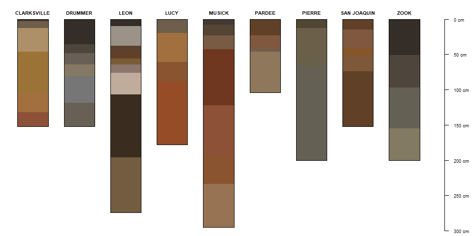

```r
# suppress printing of horizon designation
par(mar = c(0, 0, 0, 1))
plotSPC(osds, name = NA, name.style = 'center-center', divide.hz = FALSE, width = 0.33)
```